# AirBnB Seattle Analysis

This notebook is to explore AirBnB data for Seattle, following the CRISP-DM structure:

- 1) Business Understanding
- 2) Data Understanding
- 3) Preparing data
- 4) Questions: Analysing, Visualising and Explaining
- 5) Evaluating the results

The result of this study is presented as a blog post.

### 1) Business Understanding

In order to to answer the overarching question I will explore the following questions:

- What is the seasonal pattern of Airbnb in Seattle?
- What are the most requested neighborhoods in Seattle?
- What kinds of residences are most popular?
- What are the concepts hosts and guests are using to describe their residence and experiences?

### 2) Data Understanding

```python
import pandas as pd
import numpy as np
import matplotlib.pyplot as plt
from wordcloud import WordCloud
```

```python
# Import data
calendar = pd.read_csv("calendar.csv")
listings = pd.read_csv("listings.csv")
reviews = pd.read_csv("reviews.csv")
```

```python
calendar.head()
```

|  | listing_id | date | available | price |
| --- | --- | --- | --- | --- |
| 0 | 241032 | 2016-01-04 | t | $85.00 |
| 1 | 241032 | 2016-01-05 | t | $85.00 |
| 2 | 241032 | 2016-01-06 | f | NaN |
| 3 | 241032 | 2016-01-07 | f | NaN |
| 4 | 241032 | 2016-01-08 | f | NaN |

We can see at collum price there Nan's values and Dolar sign wich impact with numeric type. So it has to be fixed

```python
listings.head()
```

|  | id | listing_url | scrape_id | last_scraped | name | summary | space | description | experiences_offered | neighborhood_overview | ... | review_scores_value | requires_license | license | jurisdiction_names | instant_bookable | cancellation_policy | require_guest_profile_picture | require_guest_phone_verification | calculated_host_listings_count | reviews_per_month |
| --- | --- | --- | --- | --- | --- | --- | --- | --- | --- | --- | --- | --- | --- | --- | --- | --- | --- | --- | --- | --- | --- |
| 0 | 241032 | https://www.airbnb.com/rooms/241032 | 20160104002432 | 2016-01-04 | Stylish Queen Anne Apartment | NaN | Make your self at home in this charming one-be... | Make your self at home in this charming one-be... | none | NaN | ... | 10.0 | f | NaN | WASHINGTON | f | moderate | f | f | 2 | 4.07 |
| 1 | 953595 | https://www.airbnb.com/rooms/953595 | 20160104002432 | 2016-01-04 | Bright & Airy Queen Anne Apartment | Chemically sensitive? We've removed the irrita... | Beautiful, hypoallergenic apartment in an extr... | Chemically sensitive? We've removed the irrita... | none | Queen Anne is a wonderful, truly functional vi... | ... | 10.0 | f | NaN | WASHINGTON | f | strict | t | t | 6 | 1.48 |
| 2 | 3308979 | https://www.airbnb.com/rooms/3308979 | 20160104002432 | 2016-01-04 | New Modern House-Amazing water view | New modern house built in 2013. Spectacular s... | Our house is modern, light and fresh with a wa... | New modern house built in 2013. Spectacular s... | none | Upper Queen Anne is a charming neighborhood fu... | ... | 10.0 | f | NaN | WASHINGTON | f | strict | f | f | 2 | 1.15 |
| 3 | 7421966 | https://www.airbnb.com/rooms/7421966 | 20160104002432 | 2016-01-04 | Queen Anne Chateau | A charming apartment that sits atop Queen Anne... | NaN | A charming apartment that sits atop Queen Anne... | none | NaN | ... | NaN | f | NaN | WASHINGTON | f | flexible | f | f | 1 | NaN |
| 4 | 278830 | https://www.airbnb.com/rooms/278830 | 20160104002432 | 2016-01-04 | Charming craftsman 3 bdm house | Cozy family craftman house in beautiful neighb... | Cozy family craftman house in beautiful neighb... | Cozy family craftman house in beautiful neighb... | none | We are in the beautiful neighborhood of Queen ... | ... | 9.0 | f | NaN | WASHINGTON | f | strict | f | f | 1 | 0.89 |

5 rows × 92 columns

92 columns with a lot of features to help us in the analysis

```python
reviews.head()
```

|  | listing_id | id | date | reviewer_id | reviewer_name | comments |
| --- | --- | --- | --- | --- | --- | --- |
| 0 | 7202016 | 38917982 | 2015-07-19 | 28943674 | Bianca | Cute and cozy place. Perfect location to every... |
| 1 | 7202016 | 39087409 | 2015-07-20 | 32440555 | Frank | Kelly has a great room in a very central locat... |
| 2 | 7202016 | 39820030 | 2015-07-26 | 37722850 | Ian | Very spacious apartment, and in a great neighb... |
| 3 | 7202016 | 40813543 | 2015-08-02 | 33671805 | George | Close to Seattle Center and all it has to offe... |
| 4 | 7202016 | 41986501 | 2015-08-10 | 34959538 | Ming | Kelly was a great host and very accommodating ... |

### 3) Preparing dataset: Calendar

```python
# remove dollar sign and comma
def remove_signs(dataset, column):
    ''' Take a column name and dataset that contain dolar sign and comma,
        The function will update the dataframe with cleaned data.
    '''
    dataset[column] = dataset[column].str.replace('$','').str.replace(',','');
```

```python
# convert dataset to numeric type
def convert_to_numeric(dataset, column):
    ''' Take a column name and dataset that are object type,
        The function will change the type to numeric.
    '''
    dataset[column] = pd.to_numeric(dataset[column]);
```

```python
# transform column available to boolean
def convert_to_boolean(dataset, column):
    ''' Take a column name and dataset that are object type,
        The function will change the type to boolean.
    '''
    dataset[column] = dataset[column] == 't'
```

Let's fix the collum price replacing the Dolar sign and comma wich impact with the numeric analysis.

```python
remove_signs(calendar, 'price')
convert_to_numeric(calendar, 'price')
convert_to_boolean(calendar, 'available')
calendar.head()
```

|  | listing_id | date | available | price |
| --- | --- | --- | --- | --- |
| 0 | 241032 | 2016-01-04 | True | 85.0 |
| 1 | 241032 | 2016-01-05 | True | 85.0 |
| 2 | 241032 | 2016-01-06 | False | NaN |
| 3 | 241032 | 2016-01-07 | False | NaN |
| 4 | 241032 | 2016-01-08 | False | NaN |

### 4) What is the seasonal pattern of Airbnb in Seattle? Analysing

```python
calendar.date.value_counts().value_counts()
```

```
3818    365
Name: date, dtype: int64
```

```python
for i in calendar.date.value_counts().index.sort_values():
    print(i,end=' ')
```

[output not shown]

### 4) What is the seasonal pattern of Airbnb in Seattle? Visualising

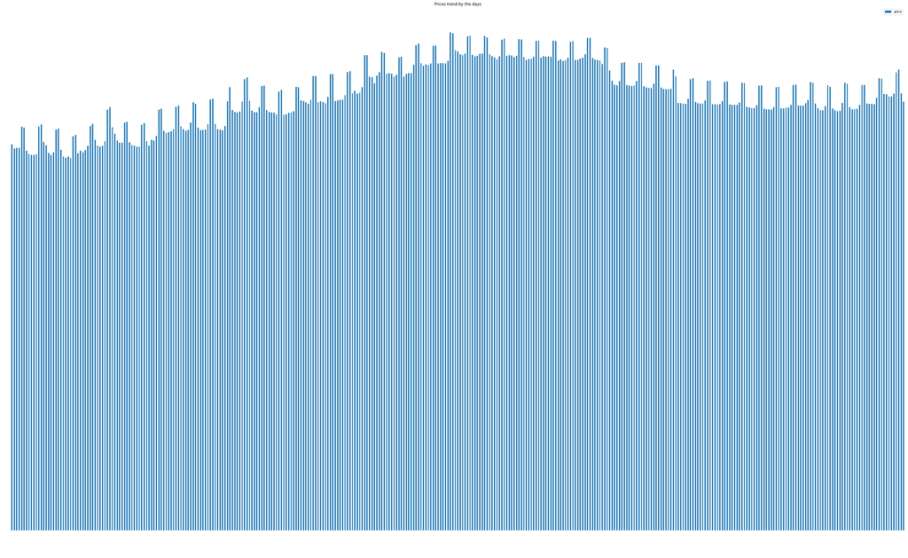

```python
day_price = pd.DataFrame(calendar.query("available == True").groupby(['date']).mean()['price'])
day_price.plot(title = "Prices trend by the days", kind = 'bar',figsize = (50,30));
plt.axis('off')
plt.show()
plt.close()
```

```python
day_price.min()
```

```
price    117.685413
dtype: float64
```

```python
day_price.max()
```

```
price    157.48
dtype: float64
```

### 4) What is the seasonal pattern of Airbnb in Seattle? Explaining:

It is possible to notice that the prices start low and increase around middle of the year, falling again in the end and are higher on every weekend during the whole year. The maximum price is 157.48 and the minimum in 117.68.

### 4) What is the seasonal pattern of Airbnb in Seattle? Visualising

```python
calendar['date'] = pd.to_datetime(calendar['date'])
```

```python
mean_of_month = calendar.groupby(calendar['date'].dt.strftime('%B'),
                                 sort=False)['price'].mean()
```

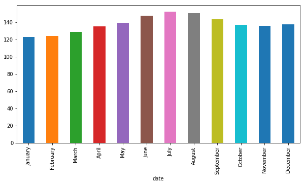

```python
mean_of_month.plot(kind = 'bar' , figsize = (10,5));
```

### 4) What is the seasonal pattern of Airbnb in Seattle? Explaining:

From the chart above we can see that the prices of accommodation are at their peak from June to August (summer) and are lowest from January to March (end of the winter).

### 3) Preparing dataset: Listings

```python
listings.head()
```

|  | id | listing_url | scrape_id | last_scraped | name | summary | space | description | experiences_offered | neighborhood_overview | ... | review_scores_value | requires_license | license | jurisdiction_names | instant_bookable | cancellation_policy | require_guest_profile_picture | require_guest_phone_verification | calculated_host_listings_count | reviews_per_month |
| --- | --- | --- | --- | --- | --- | --- | --- | --- | --- | --- | --- | --- | --- | --- | --- | --- | --- | --- | --- | --- | --- |
| 0 | 241032 | https://www.airbnb.com/rooms/241032 | 20160104002432 | 2016-01-04 | Stylish Queen Anne Apartment | NaN | Make your self at home in this charming one-be... | Make your self at home in this charming one-be... | none | NaN | ... | 10.0 | f | NaN | WASHINGTON | f | moderate | f | f | 2 | 4.07 |
| 1 | 953595 | https://www.airbnb.com/rooms/953595 | 20160104002432 | 2016-01-04 | Bright & Airy Queen Anne Apartment | Chemically sensitive? We've removed the irrita... | Beautiful, hypoallergenic apartment in an extr... | Chemically sensitive? We've removed the irrita... | none | Queen Anne is a wonderful, truly functional vi... | ... | 10.0 | f | NaN | WASHINGTON | f | strict | t | t | 6 | 1.48 |
| 2 | 3308979 | https://www.airbnb.com/rooms/3308979 | 20160104002432 | 2016-01-04 | New Modern House-Amazing water view | New modern house built in 2013. Spectacular s... | Our house is modern, light and fresh with a wa... | New modern house built in 2013. Spectacular s... | none | Upper Queen Anne is a charming neighborhood fu... | ... | 10.0 | f | NaN | WASHINGTON | f | strict | f | f | 2 | 1.15 |
| 3 | 7421966 | https://www.airbnb.com/rooms/7421966 | 20160104002432 | 2016-01-04 | Queen Anne Chateau | A charming apartment that sits atop Queen Anne... | NaN | A charming apartment that sits atop Queen Anne... | none | NaN | ... | NaN | f | NaN | WASHINGTON | f | flexible | f | f | 1 | NaN |
| 4 | 278830 | https://www.airbnb.com/rooms/278830 | 20160104002432 | 2016-01-04 | Charming craftsman 3 bdm house | Cozy family craftman house in beautiful neighb... | Cozy family craftman house in beautiful neighb... | Cozy family craftman house in beautiful neighb... | none | We are in the beautiful neighborhood of Queen ... | ... | 9.0 | f | NaN | WASHINGTON | f | strict | f | f | 1 | 0.89 |

5 rows × 92 columns

Let's fix the collum price replacing the Dolar sign and comma wich impact with the numeric analysis.

```python
remove_signs(listings, 'price')
convert_to_numeric(listings, 'price')
listings.head()
```

|  | id | listing_url | scrape_id | last_scraped | name | summary | space | description | experiences_offered | neighborhood_overview | ... | review_scores_value | requires_license | license | jurisdiction_names | instant_bookable | cancellation_policy | require_guest_profile_picture | require_guest_phone_verification | calculated_host_listings_count | reviews_per_month |
| --- | --- | --- | --- | --- | --- | --- | --- | --- | --- | --- | --- | --- | --- | --- | --- | --- | --- | --- | --- | --- | --- |
| 0 | 241032 | https://www.airbnb.com/rooms/241032 | 20160104002432 | 2016-01-04 | Stylish Queen Anne Apartment | NaN | Make your self at home in this charming one-be... | Make your self at home in this charming one-be... | none | NaN | ... | 10.0 | f | NaN | WASHINGTON | f | moderate | f | f | 2 | 4.07 |
| 1 | 953595 | https://www.airbnb.com/rooms/953595 | 20160104002432 | 2016-01-04 | Bright & Airy Queen Anne Apartment | Chemically sensitive? We've removed the irrita... | Beautiful, hypoallergenic apartment in an extr... | Chemically sensitive? We've removed the irrita... | none | Queen Anne is a wonderful, truly functional vi... | ... | 10.0 | f | NaN | WASHINGTON | f | strict | t | t | 6 | 1.48 |
| 2 | 3308979 | https://www.airbnb.com/rooms/3308979 | 20160104002432 | 2016-01-04 | New Modern House-Amazing water view | New modern house built in 2013. Spectacular s... | Our house is modern, light and fresh with a wa... | New modern house built in 2013. Spectacular s... | none | Upper Queen Anne is a charming neighborhood fu... | ... | 10.0 | f | NaN | WASHINGTON | f | strict | f | f | 2 | 1.15 |
| 3 | 7421966 | https://www.airbnb.com/rooms/7421966 | 20160104002432 | 2016-01-04 | Queen Anne Chateau | A charming apartment that sits atop Queen Anne... | NaN | A charming apartment that sits atop Queen Anne... | none | NaN | ... | NaN | f | NaN | WASHINGTON | f | flexible | f | f | 1 | NaN |
| 4 | 278830 | https://www.airbnb.com/rooms/278830 | 20160104002432 | 2016-01-04 | Charming craftsman 3 bdm house | Cozy family craftman house in beautiful neighb... | Cozy family craftman house in beautiful neighb... | Cozy family craftman house in beautiful neighb... | none | We are in the beautiful neighborhood of Queen ... | ... | 9.0 | f | NaN | WASHINGTON | f | strict | f | f | 1 | 0.89 |

5 rows × 92 columns

```python
listings.columns
```

```
Index(['id', 'listing_url', 'scrape_id', 'last_scraped', 'name', 'summary',
       'space', 'description', 'experiences_offered', 'neighborhood_overview',
       'notes', 'transit', 'thumbnail_url', 'medium_url', 'picture_url',
       'xl_picture_url', 'host_id', 'host_url', 'host_name', 'host_since',
       'host_location', 'host_about', 'host_response_time',
       'host_response_rate', 'host_acceptance_rate', 'host_is_superhost',
       'host_thumbnail_url', 'host_picture_url', 'host_neighbourhood',
       'host_listings_count', 'host_total_listings_count',
       'host_verifications', 'host_has_profile_pic', 'host_identity_verified',
       'street', 'neighbourhood', 'neighbourhood_cleansed',
       'neighbourhood_group_cleansed', 'city', 'state', 'zipcode', 'market',
       'smart_location', 'country_code', 'country', 'latitude', 'longitude',
       'is_location_exact', 'property_type', 'room_type', 'accommodates',
       'bathrooms', 'bedrooms', 'beds', 'bed_type', 'amenities', 'square_feet',
       'price', 'weekly_price', 'monthly_price', 'security_deposit',
       'cleaning_fee', 'guests_included', 'extra_people', 'minimum_nights',
       'maximum_nights', 'calendar_updated', 'has_availability',
       'availability_30', 'availability_60', 'availability_90',
       'availability_365', 'calendar_last_scraped', 'number_of_reviews',
       'first_review', 'last_review', 'review_scores_rating',
       'review_scores_accuracy', 'review_scores_cleanliness',
       'review_scores_checkin', 'review_scores_communication',
       'review_scores_location', 'review_scores_value', 'requires_license',
       'license', 'jurisdiction_names', 'instant_bookable',
       'cancellation_policy', 'require_guest_profile_picture',
       'require_guest_phone_verification', 'calculated_host_listings_count',
       'reviews_per_month'],
      dtype='object')
```

92 features. Features of interest: property_type, room_type, neighbourhood, neighbourhood_cleansed, zipcode, price, number_of_reviews, review_scores_rating, review_scores_accuracy

### 4) What are the most requested neighborhoods in Seattle? Analysing

```python
columns_of_interest = ['id', 'property_type', 'room_type', 'neighbourhood', 'neighbourhood_cleansed',
               'zipcode', 'price', 'number_of_reviews', 'review_scores_rating', 'review_scores_accuracy']

listings_interest = listings[columns_of_interest]
listings_interest.head()
```

[output not shown]

### 4) What are the most requested neighborhoods in Seattle? Visualising

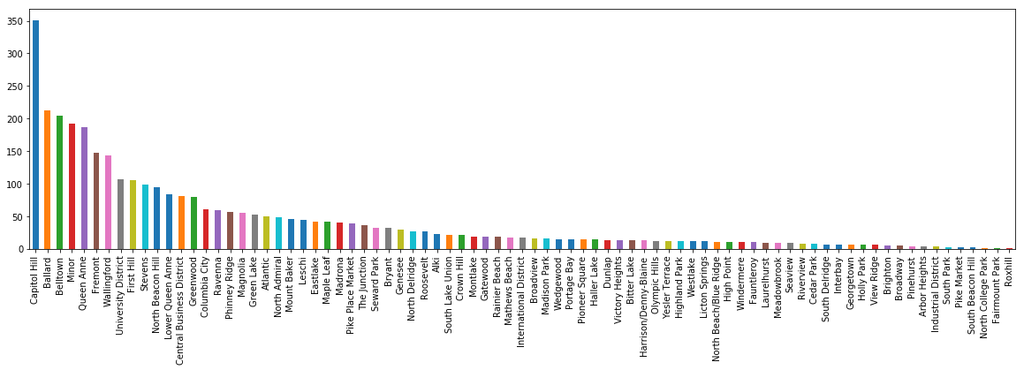

```python
listings_interest['neighbourhood'].value_counts().plot(kind = 'bar' , figsize = (20,5));
```

### 4) What are the most requested neighborhoods in Seattle? Explaining:

The proportion of requests related to each neighborhood is presented in descending order in the plot above. The winner is Capitol Hill neighborhood, the second place are Ballard, Belltown, Minor and Queen Anne neighborhoods and in the third are Fremont and Wallingford neighborhoods.

### 4) What kinds of residences are most popular? Analysing and Visualising:

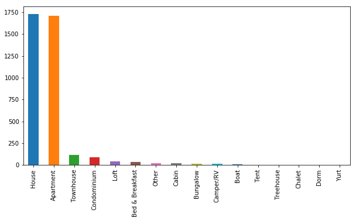

```python
listings_interest['property_type'].value_counts().plot(kind = 'bar' , figsize = (10,5));
```

### 4) What kinds of residences are most popular? Explaining:

From above chart we see that houses and apartment have together 90% of the total listings.

```python
listings['review_scores_value'].value_counts()
```

```
10.0    1775
9.0     1137
8.0      190
7.0       38
6.0       16
4.0        4
5.0        1
2.0        1
Name: review_scores_value, dtype: int64
```

### 3) Preparing dataset: Reviews

```python
reviews.head()
```

|  | listing_id | id | date | reviewer_id | reviewer_name | comments |
| --- | --- | --- | --- | --- | --- | --- |
| 0 | 7202016 | 38917982 | 2015-07-19 | 28943674 | Bianca | Cute and cozy place. Perfect location to every... |
| 1 | 7202016 | 39087409 | 2015-07-20 | 32440555 | Frank | Kelly has a great room in a very central locat... |
| 2 | 7202016 | 39820030 | 2015-07-26 | 37722850 | Ian | Very spacious apartment, and in a great neighb... |
| 3 | 7202016 | 40813543 | 2015-08-02 | 33671805 | George | Close to Seattle Center and all it has to offe... |
| 4 | 7202016 | 41986501 | 2015-08-10 | 34959538 | Ming | Kelly was a great host and very accommodating ... |

```python
reviews.shape
```

```
(84849, 6)
```

### 4) What are the concepts hosts and guests are using to describe their residence and experiences? Analysing

```python
for i in reviews.date.value_counts().index.sort_values():
    print(i,end=' ')
```

[output not shown]

### 4) What are the concepts hosts and guests are using to describe their residence and experiences? Visualising

```python
wc = WordCloud(background_color="white",width=1000, height=1000, margin=2).generate(str(reviews['comments']))
```

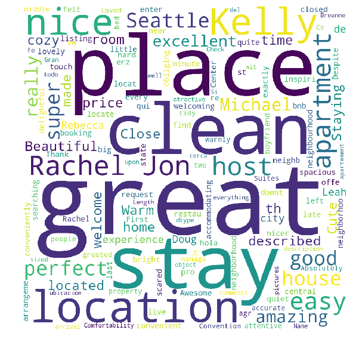

```
<wordcloud.wordcloud.WordCloud at 0x7f6225ddacc0>
```

```python
plt.figure(figsize=(10,10))
plt.imshow(wc)
plt.axis('off')
plt.show()
wc.to_file('Comments.png')
```

### 4) What are the concepts hosts and guests are using to describe their residence and experiences? Explaining

It is possible to see that absolute most are positive comments and that guests care a lot about cleanness and location.

### 4) What are the concepts hosts and guests are using to describe their residence and experiences? Visualising

```python
wc = WordCloud(background_color="white",width=1000, height=1000, margin=2).generate(str(listings['description']))
```

[figure not shown]

```
<wordcloud.wordcloud.WordCloud at 0x7f622969c588>
```

```python
plt.figure(figsize=(10,10))
plt.imshow(wc)
plt.axis('off')
plt.show()
wc.to_file('Description.png')
```

### 4) What are the concepts hosts and guests are using to describe their residence and experiences? Explaining

This plot shows “bedroom”, “apartment” and “private” as biggest words indicating the features that are most presented in the residence descriptions. It is possible to find the emphasis on some conveniences such as “comfortable”, “charming” and “cozy”.

### Evaluation

We took a look at some valuable information about AirBnB rental in Seattle such the seasonal price pattern during the year, identifying the most demanded neighborhoods, the most popular residences and dominant concepts used by hosts and gests.